# ÜLESANNE 1. Graafid

NTR0390 Algoritmid ja andmestruktuurid. Moodul GRAAFID

õpilane Toomas Kirsing

23.09.2022

Graafiteooria ülesannete lahendamiseks tarkvara R ja RStudio abil on vaja installida lisapaketid *igraph* ja *network* ning aktiveerida neid

```r
library(igraph)
library(network)
```

# Orienteeritud graaf

### Graafi moodustamine

Esitan üliõpilaskoodi (212452) 2nd süsteemis

```r
library(R.utils)
a <- as.integer(unlist(strsplit(intToBin(212452),split="")))
```

Sisestan maatriksi *K* read ülesandes antud eeskirja järgi

```r
matrK <- rbind(a[1:5],a[6:10],a[c(11:12,1:3)],a[4:8],a[9:13])
matrK
```

```
##      [,1] [,2] [,3] [,4] [,5]
## [1,]    1    1    0    0    1
## [2,]    1    1    1    0    1
## [3,]    1    1    1    1    0
## [4,]    0    1    1    1    1
## [5,]    0    1    1    1    1
```

Moodustan graafi funktsiooni *graph_from_adjacency_matrix()* abil ja joonestan funktsiooniga *plot()*:

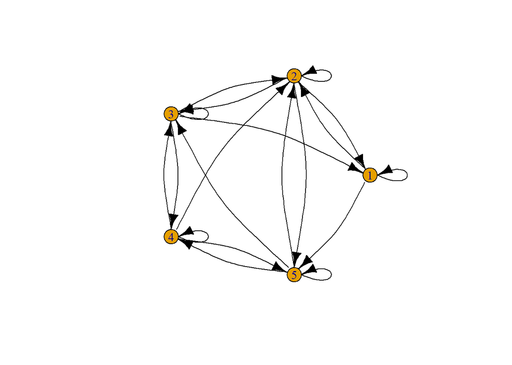

```r
g <- graph_from_adjacency_matrix(matrK)
plot(g,layout=layout_in_circle, edge.curved=0.2,edge.color="black")
```

### Intsidentsusmaatriks

Orienteeritud graafi intsidentsusmaatriks:

```r
netw <- as.network.matrix(matrK,mode="directed", loops=TRUE)
matrI <- as.matrix(netw,matrix.type="incidence", loops=TRUE)
nodes_loops <- as.matrix(get.edgelist(g))[which_loop(g)==TRUE,1]
if(is.matrix(matrI[nodes_loops,colSums(abs(matrI))==0])==FALSE){
  matrI[nodes_loops,colSums(abs(matrI))==0] <- 1
} else {
  diag(matrI[nodes_loops,colSums(abs(matrI))==0]) <- 1
}

matrI
```

```
##      [,1] [,2] [,3] [,4] [,5] [,6] [,7] [,8] [,9] [,10] [,11] [,12] [,13] [,14]
## [1,]    1    1    1   -1    0    0    0    0    0     0     0     0     0     0
## [2,]    0   -1    0    1    1    1    1    1   -1     0     0     0     0     0
## [3,]    0    0   -1    0    0   -1    0    0    1     1     1     1    -1     0
## [4,]    0    0    0    0    0    0   -1    0    0     0    -1     0     1     1
## [5,]    0    0    0    0    0    0    0   -1    0     0     0    -1     0     0
##      [,15] [,16] [,17] [,18] [,19]
## [1,]     0    -1     0     0     0
## [2,]     0     0    -1     0     0
## [3,]     0     0     0     0     0
## [4,]     1     0     0    -1     0
## [5,]    -1     1     1     1     1
```

### Graafi servade ja tippude loendid

Graafi servade loend kasutades funktsiooni *get.edgelist()*:

```r
get.edgelist(g, names = 1)
```

```
##       [,1] [,2]
##  [1,]    1    1
##  [2,]    1    2
##  [3,]    1    5
##  [4,]    2    1
##  [5,]    2    2
##  [6,]    2    3
##  [7,]    2    5
##  [8,]    3    1
##  [9,]    3    2
## [10,]    3    3
## [11,]    3    4
## [12,]    4    2
## [13,]    4    3
## [14,]    4    4
## [15,]    4    5
## [16,]    5    2
## [17,]    5    3
## [18,]    5    4
## [19,]    5    5
```

Graafi naabrustippude loend funktsioonist *get.adjlist()*:

```r
get.adjlist(g,mode = "out")
```

```
## [[1]]
## + 3/5 vertices, from 4298e85:
## [1] 1 2 5
##
## [[2]]
## + 4/5 vertices, from 4298e85:
## [1] 1 2 3 5
##
## [[3]]
## + 4/5 vertices, from 4298e85:
## [1] 1 2 3 4
##
## [[4]]
## + 4/5 vertices, from 4298e85:
## [1] 2 3 4 5
##
## [[5]]
## + 4/5 vertices, from 4298e85:
## [1] 2 3 4 5
```

### Graafi tihedus

Definitsiooni järgi orienteeritud graaf on tihe (*dense*) siis, kui servade arv on täisgraafi servade arvuga $|V|^2$ lähedasem, ja graaf on hõre (*sparse*) siis, kui servade arv on tippude arvuga $|V|$ lähedasem.

Antud graafi servade arv:

```r
gsize(g)
```

```
## [1] 19
```

Antud graafi servade arv 19 on rohkem lähedane täisgraafi servade arvuga $|V|^2$ =25, kui tippude arvuga $|V|$ =5, seega antud graaf on tihe.

### Graafi tippude astmed

Orienteeritud graafi tipu väljundastmed:

```r
degree(g,mode = "out")
```

```
## [1] 3 4 4 4 4
```

Orienteeritud graafi tipu sisendastmed:

```r
degree(g,mode = "in")
```

```
## [1] 3 5 4 3 4
```

**Loeng 1 Omadus 1:** Orienteeritud graafi korral graafi tippude sisend- ja väljundastmete summad on omavahel võrdsed ning võrduvad graafi servade arvuga:

```r
sum(degree(g,mode = "out")) # tippude väljundastmete summa
```

```
## [1] 19
```

```r
sum(degree(g,mode = "in")) # tippude sisendastmete summa
```

```
## [1] 19
```

```r
gsize(g) # graafi servade arv
```

```
## [1] 19
```

Omadus on kehtiv.

### Isoleeritud ja rippuvad tipud

Orienteeritud graafi korral rippuvate ja isoleeritud tippude leidmiseks alguses lihtsustame graafi, eemaldades graafist kõik silmused.

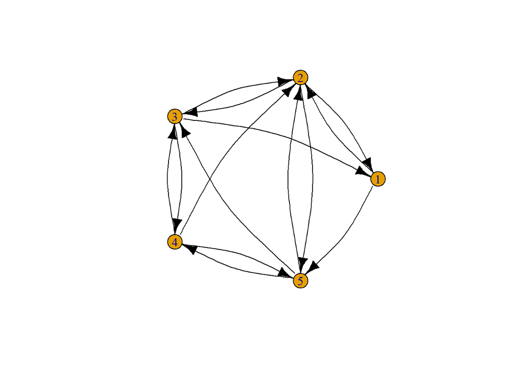

```r
g1 <- simplify(g, remove.multiple = TRUE, remove.loops = TRUE,
  edge.attr.comb = igraph_opt("edge.attr.comb"))
plot(g1,layout=layout_in_circle, edge.curved=0.2,edge.color="black")
```

**Isoleeritud tipud:** tipud, millega intsidenseid servi pole (pärast silmuste eemaldamist summaarne aste on 0) on isoleeritud tipud.

```r
d_all <- degree(g1,mode = "all")
d_all
```

```
## [1] 4 7 6 5 6
```

```r
which(d_all==0) #isoleeritud tipud
```

```
## integer(0)
```

Antud graafi korral isoleeritud tipud puuduvad

**Rippuvad tipud:** tipud ainult ühe naabertipuga on rippuvad tipud. Rippuva tipu korral, kas korraga sisend- ja väljundastmed on ühed, või sisendaste = 1 ja väljundaste = 0, või sisendaste = 0 ja väljundaste = 1. Kasutame naabertippude loendit, suunda arvestamata (mode = “all”) ja kui seos on kahesuunaline, võtame arvesse naabreid ainult ühekorselt

```r
neighbour_all=lapply(get.adjlist(g1,mode = "all"), unique)
neighbour_all
```

```
## [[1]]
## + 3/5 vertices, from 42be56e:
## [1] 2 3 5
##
## [[2]]
## + 4/5 vertices, from 42be56e:
## [1] 1 3 4 5
##
## [[3]]
## + 4/5 vertices, from 42be56e:
## [1] 1 2 4 5
##
## [[4]]
## + 3/5 vertices, from 42be56e:
## [1] 2 3 5
##
## [[5]]
## + 4/5 vertices, from 42be56e:
## [1] 1 2 3 4
```

siis tippude naabrite arvud:

```r
neighbour_nmbr=lengths(neighbour_all)
neighbour_nmbr
```

```
## [1] 3 4 4 3 4
```

Kontrollime naabreid: rippuval tipul on ainult üks naaber

```r
which(neighbour_nmbr==1)
```

```
## integer(0)
```

Antud graafil puudub rippuv tipp.

# Orienteerimata graaf

### Graafi moodustamine

Orienteerimata lihtgraafi korral graafi naabrusmaatriks *K* on sümmeetriline ja tema peadiagonaalil on nullid.

```r
library(R.utils)
a <- as.integer(unlist(strsplit(intToBin(212452),split="")))
row1 <- c(0,a[1],a[2],a[4],a[7],a[11])
row2 <- c(a[1],0,a[3],a[5],a[8],a[12])
row3 <- c(a[2],a[3],0,a[6],a[9],a[13])
row4 <- c(a[4],a[5],a[6],0,a[10],a[14])
row5 <- c(a[7],a[8],a[9],a[10],0,a[15])
row6 <- c(a[11],a[12],a[13],a[14],a[15],0)
matrK <- rbind(row1,row2,row3,row4,row5,row6)
matrK
```

```
##      [,1] [,2] [,3] [,4] [,5] [,6]
## row1    0    1    1    0    1    1
## row2    1    0    0    1    1    1
## row3    1    0    0    1    0    1
## row4    0    1    1    0    1    0
## row5    1    1    0    1    0    0
## row6    1    1    1    0    0    0
```

Moodustan graafi funktsiooni *graph_from_adjacency_matrix()* abil ja joonestan funktsiooniga *plot()*:

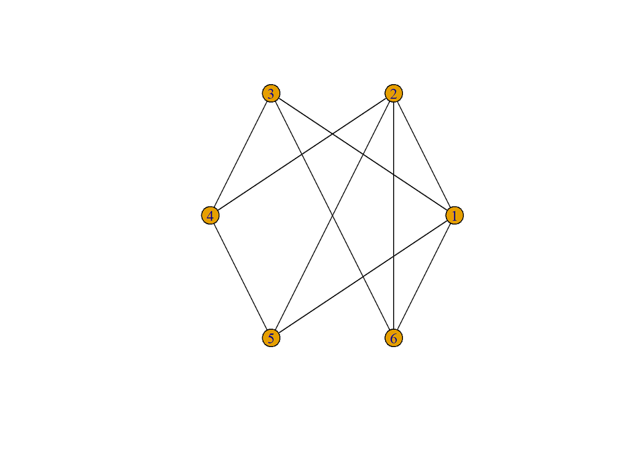

```r
g <- graph_from_adjacency_matrix(matrK, mode="undirected")
plot(g,layout=layout_in_circle, edge.color="black")
```

### Intsidentsusmaatriks

Orienteerimata graafi intsidentsusmaatriks:

```r
netw <- as.network.matrix(matrK,directed = F, loops=F)
matrI <- as.matrix(netw,matrix.type="incidence", loops=F)

matrI
```

```
##      [,1] [,2] [,3] [,4] [,5] [,6] [,7] [,8] [,9] [,10]
## [1,]    1    1    1    1    0    0    0    0    0     0
## [2,]    1    0    0    0    1    1    1    0    0     0
## [3,]    0    1    0    0    0    0    0    1    1     0
## [4,]    0    0    0    0    1    0    0    1    0     1
## [5,]    0    0    1    0    0    1    0    0    0     1
## [6,]    0    0    0    1    0    0    1    0    1     0
```

### Graafi servade ja tippude loendid

Graafi servade loend:

```r
get.edgelist(g, names = 1)
```

```
##       [,1] [,2]
##  [1,]    1    2
##  [2,]    1    3
##  [3,]    1    5
##  [4,]    1    6
##  [5,]    2    4
##  [6,]    2    5
##  [7,]    2    6
##  [8,]    3    4
##  [9,]    3    6
## [10,]    4    5
```

Graafi naabrustippude loend:

```r
get.adjlist(g,mode = "all")
```

```
## [[1]]
## + 4/6 vertices, from 42dadbd:
## [1] 2 3 5 6
##
## [[2]]
## + 4/6 vertices, from 42dadbd:
## [1] 1 4 5 6
##
## [[3]]
## + 3/6 vertices, from 42dadbd:
## [1] 1 4 6
##
## [[4]]
## + 3/6 vertices, from 42dadbd:
## [1] 2 3 5
##
## [[5]]
## + 3/6 vertices, from 42dadbd:
## [1] 1 2 4
##
## [[6]]
## + 3/6 vertices, from 42dadbd:
## [1] 1 2 3
```

### Graafi tihedus

Definitsiooni järgi orienteerimata graaf on tihe (*dense*) siis, kui servade arv on täisgraafi servade arvuga $|V|*(|V|-1)/2$ lähedasem, ja graaf on hõre (*sparse*) siis, kui servade arv on tippude arvuga $|V|$ lähedasem.

Antud graafi servade arv:

```r
gsize(g)
```

```
## [1] 10
```

### Graafi tippude astmed

Orienteerimata graafi tipu astmed:

```r
degree(g,mode = "all")
```

```
## [1] 4 4 3 3 3 3
```

*Loeng 1 Omadus 2:* Orienteerimata graafi korral tippude astmete summa on kaks korda suurem kui graafi servade arv

```r
sum(degree(g,mode = "all")) # tippude astmete summa
```

```
## [1] 20
```

```r
gsize(g) # graafi servade arv
```

```
## [1] 10
```

Omadus kehtib.

### Isoleeritud ja rippuvad tipud

Orienteerimata graafi korral rippuvate ja isoleeritud tippude leidmiseks vaatame graafi tippude astmed, mis näitavad tipuga intsidentsete servade arvu

```r
degree(g) # näitab iga tipuga intsidentsete servade arvu
```

```
## [1] 4 4 3 3 3 3
```

**Isoleeritud tipud** on tipud, millega itsidenseid servi pole ehk tipu aste on 0. Antud graafis isoleeritud tipud puuduvad:

```r
which(degree(g)==0) #isoleeritud tipud
```

```
## integer(0)
```

Isoleeritud tipud puuduvad

**Rippuvad tipud** on ainult ühe naabertipuga tipud ehk tipu aste on 1.

Antud graafi korral rippuvad tipud puuduvad:

```r
which(degree(g,mode = "all")==1)
```

```
## integer(0)
```

Rippuvad tipud puuduvad

# Graaf etteantud tippude astmetega

Tippude astmetega 2, 1, 2, 4, 5, 2 graaf eksisteerib ja seda on võimalik joonestada:

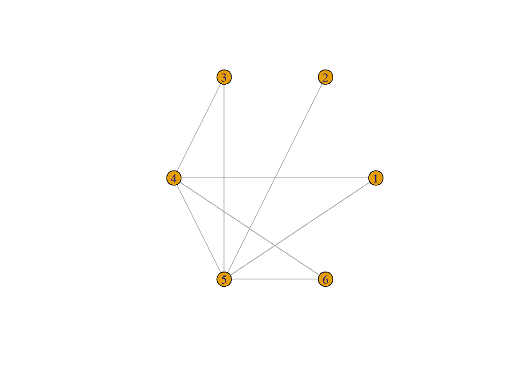

```r
plot(sample_degseq(c( 2, 1, 2, 4, 5, 2),method="vl"),layout=layout_in_circle)
```

# Täisgraafi moodustamine

Täisgraafi *n* tipul moodustame funktsiooniga *make_full_graph(n)*:

## a)

### Graaf a+6

a = 2, tippe peab olema 8:

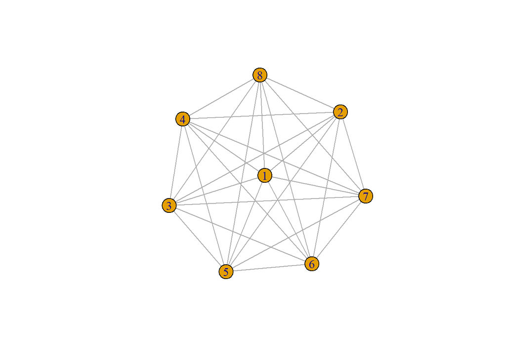

```r
gf <- make_full_graph(8)
plot(gf)
```

### Tippude astmed

Antud graafi kõikide tippude astmed on 7:

```r
degree(gf,mode = "all")
```

```
## [1] 7 7 7 7 7 7 7 7
```

### Servade arv

Antud graafi servade arv on 28:

```r
gsize(gf)
```

```
## [1] 28
```

## b)

# Kasutatud materjal

Õppematerjal moodles. Etteantud vormistuse näidis.